# Assignment 3.2P

2022 Programming in Psychological Science

### Assignment description

Work through the following 8 Python problems and 1 Python package. This assignment is worth 2 points, with each problem worth 0.2 points and the Python package worth 0.4 points. The total of Assignments 3.1 and your choice of either 3.2P (Python) or 3.2R (R challenge) are worth 10 points and 15% of your final course grade (just like the other assignments). You must work individually, but feel free to ask questions in class and on Slack!

You must submit the problems as a Python script (.py file). All answers must have comments and be labeled with the problem number. **The script should export figures to the current working directory.** Some answers will only be comments without associated Python code. For questions about output, report your output in a comment under the relevant line of code. Note that all comments have `#` in front of them so that Python does not run this line of code.

This weeks assignment has a lot of exercises that you can tackle in different ways. So if you want to use a different approach or package than your classmates, that is fine! We also do not mind what colors you pick for your plots or if font sizes slightly differ. However, always make sure that you practice good, clear, and efficient coding style.

Note that you can activate interactive plotting in the IPython console using the IPython magic command `%pylab`. These magic commands do not work inside Python scripts. Read more about magic commands here: https://ipython.readthedocs.io/en/stable/interactive/magics.html

## Q3.2P.1 (0.2 points)

Simulate some data and show them in a `plt.boxplot()` using matplotlib. Now create a `sns.violinplot()` with “jittered” data points using `sns.stripplot()` with the same data using the seaborn package. Make sure you can see the data points!

What does one half of the violin plot represent?

In your option, which plot is a more informative of visualizing your data (this will not graded on correctness)?

## Q3.2P.2 (0.2 points)

The day that the titanic sank, was a bad day in many ways. Most importantly, because it helps present-day men to justify pro-male sexism with plots like this.

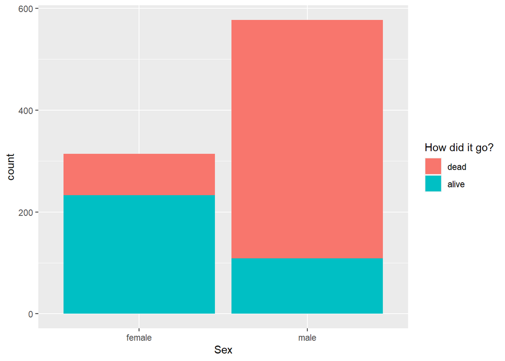

Can you recreate the bar plot with matplotlib? The example plot is made in R, so your Python plot will likely end up having a somewhat different style. That is fine as long as the basic setup and logic of the plot is the same.

When reading in the titanic csv file please do not use a path pointing to a location on your computer like “documents/titanic.csv” but rather read the data directly from the web (e.g., here https://raw.githubusercontent.com/hannesrosenbusch/schiphol_class/master/titanic.csv).

## Q3.2P.3 (0.2 points)

Load the wine dataset from the sklearn.datasets module. Make a scatter plot of the wines with `malic_acid` on the x axis and `alcohol` on the y axis. Add a regression line to the plot. Label your x-axis and y-axis with the variable names in large font size.

## Q3.2P.4 (0.2 points)

Make a plot of two subplots next to eachother. Plot a heatmap showing all the correlations between the variables in the wine dataset. Next to the heatmap, add a `kdeplot` with alcohol on the x axis and color_intensity on the y axis.

## Q3.2P.5 (0.2 points)

Define a function my_plots that takes a string as input (i.e., it has one argument) and generates a plot. If the string is “eww” it generates a confusing, non-informative plot. If the string is “yay” it prints a clear, informative plot. All other inputs lead to reminders that the function should be either used with “eww” or “yay”.

## Q3.2P.6 (0.2 points)

Look through your solutions from any previous Python exercises (this week or in previous weeks) where you wrote your own Python code. Improve style of of your code by following PEP8 (Python Enhancement Proposal 8) guidelines: https://www.python.org/dev/peps/pep-0008/. Note that you can use a pylint or another Python “linter”: https://pylint.org/.

Also change variable names to be more informative and write some comments so that someone else can read your code.

Attach both the old code and new code here that is clearly labeled `# Old bad code` and `# New good code`. Explain what you did to change your code to PEP8 and discuss how else you improved your code. If your old code was already perfect explain why.

## Q3.2P.7 (0.2 points)

Many conventions and style guidelines for Python code are universally accepted. However, sometimes there is controversy about “the best way to do things”. Find one of these issues and state in two brief sentences which side you are on.

## Q3.2P.8 (0.2 points)

Michael is a sloppy Python coder: https://github.com/mdnunez/pyhddmjags/blob/master/pyhddmjagsutils.py Choose one of his functions to improve by using a pylint and creating better variable names and comments. Explain what you did to change his code to PEP8 and discuss how else you improved his code. If his old code was already perfect explain why.

## Q3.2P.9 (0.4 points)

Make an Python repository and publish it on https://github.com or https://gitlab.com/ or a similar website that uses git. The Python package will contain one function `cheat()`. The `cheat()` function should take one argument specifying which exercise of any previous Python assignment the user of your package wants to cheat on. Given the exercise number, your `cheat()`function tells the user the correct solution. The cheat function should work for at least 4 exercises.

You should also create a README file for your Python repository using Markdown.

You are free to reuse this function in the exam :).